# Project 4: Document Classification

### Introduction

For this project, I will be classifying emails using the ham and spam dataset. I will use Naive Bayes Algorithm to create a model. After creating the model, I will predict the model and check the accuracy of the model.

### Data Loading

I need to change the data into a usable form, before classifying the emails. This process involves reading in the emails, putting the emails into a dataframe, creating the corpus, and creating a document term matrix and use the data to train models for classfication.

Loading required libraries.

```r
library(dplyr)
library(tidytext)
library(tm)
library(stringr)
library(DT)
library(readtext)
library(wordcloud)
library(e1071)
library(gmodels)
```

### Text processing and transformation

Download the zip files from https://spamassassin.apache.org/old/publiccorpus/. Unzip and paste the files in my working directory. Selected `20021010_spam.tar` and `20021010_easy_ham.tar` file to do the classification.

Read the files from easy_ham and spam folder. I Created a user-defined function which read each email present in the folders.

```r
ham_diretory="/Users/subhalaxmirout/DATA607 Lab1/Project 4/easy_ham"
ham_file_names = list.files(ham_diretory)

# List of docs, aassign a list with "NA"
ham_docs_list <- NA
# using for loop read file one by one stored all the ham emails in a list
for(i in 1:length(ham_file_names))
{
  file_path<-paste0(ham_diretory, "/", ham_file_names[1])
  text <-readLines(file_path)
  ham_list<- list(paste(text, collapse="\n"))
  ham_docs_list = c(ham_docs_list,ham_list)

}

# set the data as a data frame
ham_df <-as.data.frame(unlist(ham_docs_list),stringsAsFactors = FALSE)
#
ham_df$type <- "ham"
# rename the column name
colnames(ham_df) <- c("text","type")

# Create Spam Dataframe
spam_diretory="/Users/subhalaxmirout/DATA607 Lab1/Project 4/spam"
spam_file_names = list.files(spam_diretory)

spam_docs_list <- NA
for(i in 1:length(spam_file_names))
{
  file_path<-paste0(spam_diretory, "/", spam_file_names[1])
  text <-readLines(file_path)
  spam_list<- list(paste(text, collapse="\n"))
  spam_docs_list = c(spam_docs_list,spam_list)

}

# set the data as a data frame
spam_df <-as.data.frame(unlist(spam_docs_list),stringsAsFactors = FALSE)
spam_df$type <- "spam"
# rename the column name
colnames(spam_df) <- c("text","type")
```

Combine the dataset into one data frame.

```r
# creating combined data frame of spam and ham
spam_ham_df <- rbind(ham_df, spam_df)
spam_ham_df = cbind(spam_ham_df,DocID = seq(1,length(spam_ham_df$text)))
tibble::tibble(spam_ham_df)
```

```
## # A tibble: 3,054 x 3
##    text                                                              type  DocID
##    <chr>                                                             <chr> <int>
##  1  <NA>                                                             ham       1
##  2 "From exmh-workers-admin@redhat.com  Thu Aug 22 12:36:23 2002\nR… ham       2
##  3 "From exmh-workers-admin@redhat.com  Thu Aug 22 12:36:23 2002\nR… ham       3
##  4 "From exmh-workers-admin@redhat.com  Thu Aug 22 12:36:23 2002\nR… ham       4
##  5 "From exmh-workers-admin@redhat.com  Thu Aug 22 12:36:23 2002\nR… ham       5
##  6 "From exmh-workers-admin@redhat.com  Thu Aug 22 12:36:23 2002\nR… ham       6
##  7 "From exmh-workers-admin@redhat.com  Thu Aug 22 12:36:23 2002\nR… ham       7
##  8 "From exmh-workers-admin@redhat.com  Thu Aug 22 12:36:23 2002\nR… ham       8
##  9 "From exmh-workers-admin@redhat.com  Thu Aug 22 12:36:23 2002\nR… ham       9
## 10 "From exmh-workers-admin@redhat.com  Thu Aug 22 12:36:23 2002\nR… ham      10
## # … with 3,044 more rows
```

### Create Corpus dataset

Create a corpus data set and clean the data such as remove numbers, punctuations, stops words, and whitespace etc.

```r
# create corpus
Corpus <- Corpus(VectorSource(spam_ham_df$text))
Corpus <- tm_map(Corpus, removeNumbers)
Corpus <- tm_map(Corpus, removePunctuation)
Corpus <- tm_map(Corpus, removeWords, stopwords())
Corpus <- tm_map(Corpus, stripWhitespace)
```

### Word cloud

Create word cloud for spam emails and ham emails, to see the most frequent words used for spam and ham.

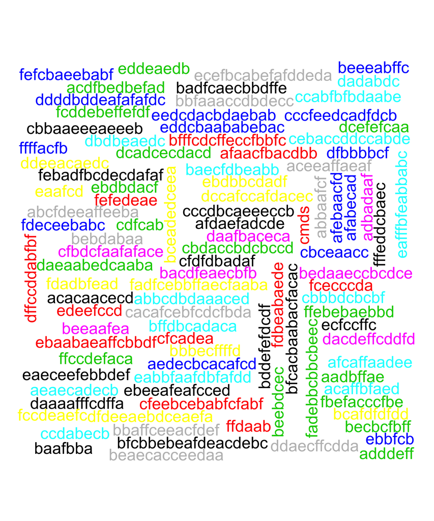

```r
# word cloud for spam emails
dtm <- DocumentTermMatrix(Corpus)

spam_indices <- which(spam_ham_df$type == "spam")
suppressWarnings(wordcloud(Corpus[spam_indices], min.freq=50,random.color = TRUE,colors=palette()))
```

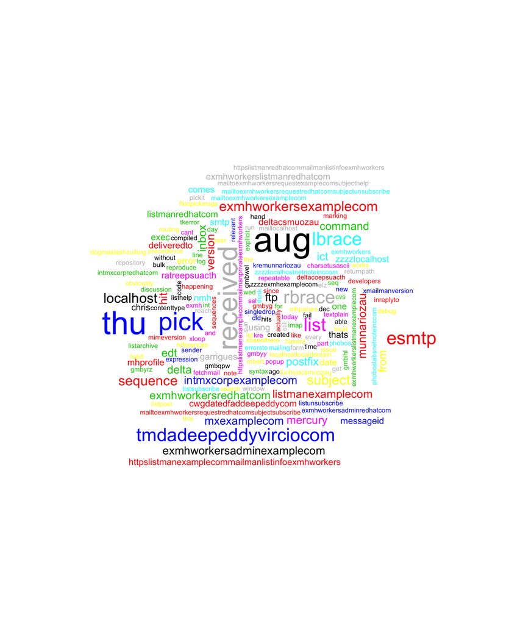

```r
# word cloud for ham emails
ham_indices <- which(spam_ham_df$type == "ham")
suppressWarnings(wordcloud(Corpus[ham_indices], min.freq=50,random.color = TRUE,colors=palette()))
```

### Train and Test data

Divided data set in to 2 part train and test. Train data contains 70% of data and test contains 30% of data.

```r
# sample 70% data traning and 30 % for prediction
sample_df <- floor(0.70 * nrow(spam_ham_df))

# set the seed to make result reproductible
set.seed(124)
train_ind <- sample(seq_len(nrow(spam_ham_df)), size = sample_df)

train_spam_ham <- spam_ham_df[train_ind, ]
test_spam_ham <- spam_ham_df[-train_ind, ]

# count of spam and ham in train data set
spam<-subset(train_spam_ham,train_spam_ham$type == "spam")
ham<-subset(train_spam_ham,train_spam_ham$type == "ham")

# Create corpus for training and test data
train_corpus <- Corpus(VectorSource(train_spam_ham$text))
test_corpus <- Corpus(VectorSource(test_spam_ham$text))

# Remove numbers
train_corpus <- tm_map(train_corpus ,removeNumbers)
test_corpus <- tm_map(test_corpus, removeNumbers)
# Remove punctuations
train_corpus <- tm_map(train_corpus, removePunctuation)
test_corpus <- tm_map(test_corpus, removePunctuation)
# Remove stop words
train_corpus <- tm_map(train_corpus, removeWords, stopwords())
test_corpus  <- tm_map(test_corpus, removeWords, stopwords())
# Remove white spaces
train_clean_corpus<- tm_map(train_corpus, stripWhitespace)
test_clean_corpus<- tm_map(test_corpus, stripWhitespace)
# Create corpus for train and test
train_dtm <- DocumentTermMatrix(train_corpus)
test_dtm <- DocumentTermMatrix(test_corpus)

# count function
convert_count <- function(x) {
  y <- ifelse(x > 0, 1,0)
  y <- factor(y, levels=c(0,1), labels=c("No", "Yes"))
  y
}

train_sample <- apply(train_dtm, 2, convert_count)
test_sample <- apply(test_dtm, 2, convert_count)
```

### Modeling

Create model using Naive Bayes Algorithm and find the accuracy.

```r
# classification of email
classifier_nb <- naiveBayes(train_sample, factor(train_spam_ham$type))

test_pred_nb <- predict(classifier_nb, newdata=test_sample)

prop.table(table(test_pred_nb, test_spam_ham$type))
```

```
##
## test_pred_nb       ham      spam
##         ham  0.8222465 0.0000000
##         spam 0.0000000 0.1777535
```

```r
CrossTable(test_pred_nb,test_spam_ham$type, prop.chisq = FALSE,prop.t = FALSE, dnn = c("Predicted", "Actual"))
```

```
##
##
##    Cell Contents
## |-------------------------|
## |                       N |
## |           N / Row Total |
## |           N / Col Total |
## |-------------------------|
##
##
## Total Observations in Table:  917
##
##
##              | Actual
##    Predicted |       ham |      spam | Row Total |
## -------------|-----------|-----------|-----------|
##          ham |       754 |         0 |       754 |
##              |     1.000 |     0.000 |     0.822 |
##              |     1.000 |     0.000 |           |
## -------------|-----------|-----------|-----------|
##         spam |         0 |       163 |       163 |
##              |     0.000 |     1.000 |     0.178 |
##              |     0.000 |     1.000 |           |
## -------------|-----------|-----------|-----------|
## Column Total |       754 |       163 |       917 |
##              |     0.822 |     0.178 |           |
## -------------|-----------|-----------|-----------|
##
##
```

### Summary

- Analysis of word counts in the Spam and Ham emails revealed differences in the most commonly occurring words.
- Accuracy of Naive Bayes model is 100%.

##### References

- https://www.youtube.com/watch?v=qjSeedeF4KQ
- https://www.youtube.com/watch?v=sujx3MjEH_0